# FIT3181: Deep Learning (2024)

*Lecturer (Malaysia):* **Dr Arghya Pal** | arghya.pal@monash.edu  
*Lecturer (Malaysia):* **Dr Lim Chern Hong** | lim.chernhong@monash.edu

*CE/Lecturer (Clayton):* **Dr Trung Le** | trunglm@monash.edu  
*Lecturer (Clayton):* **Prof Dinh Phung** | dinh.phung@monash.edu

School of Information Technology, Monash University, Malaysia  
Faculty of Information Technology, Monash University, Australia

# Student Information

Surname: **Beh**  
Firstname: **Hanyu**  
Student ID: **33607265**  
Email: **hbeh0003@student.monash.edu**  
Your tutorial time: **Thursday 12pm**

**[Very Important]**  
Make a copy of thus Google colab notebook including the traces and progresses of model training before submitting.**

# Deep Neural Networks

### Due: 11:55pm Wednesday, 11 September 2024 (Wednesday)

#### Important note: This is an **individual** assignment. It contributes **25%** to your final mark. Read the assignment instructions carefully.

## What to submit

This assignment is to be completed individually and submitted to Moodle unit site. **By the due date, you are required to submit one single zip file, named xxx_assignment01_solution.zip where `xxx` is your student ID, to the corresponding Assignment (Dropbox) in Moodle**. You can use Google Colab to do Assigmnent 1 but you need to save it to an `*.ipynb` file to submit to the unit Moodle.

**More importantly, if you use Google Colab to do this assignment, you need to first make a copy of this notebook on your Google drive**.

*For example, if your student ID is 12356, then gather all of your assignment solution to folder, create a zip file named 123456_assignment01_solution.zip and submit this file.*

Within this zip folder, you **must** submit the following files:

1. **Assignment01_solution.ipynb**: this is your Python notebook solution source file.
2. **Assignment01_output.html**: this is the output of your Python notebook solution *exported* in html format.
3. Any **extra files or folder** needed to complete your assignment (e.g., images used in your answers).

```python
!jupyter nbconvert --to html /content/Assignment01_solution.ipynb
```

```
[NbConvertApp] Converting notebook /content/Assignment01_solution.ipynb to html
[NbConvertApp] Writing 2883878 bytes to /content/Assignment01_solution.html
```

Since the notebook is quite big to load and work together, one recommended option is to split solution into three parts and work on them seperately. In that case, replace **Assignment01_solution.ipynb** by three notebooks: **Assignment01_Part1_solution.ipynb**, **Assignment01_Part2_solution.ipynb** and **Assignment01_Part3_solution.ipynb**

## Part 1: Theory and Knowledge Questions

[Total marks for this part: 30 points]

The first part of this assignment is to demonstrate your knowledge in deep learning that you have acquired from the lectures and tutorials materials. Most of the contents in this assignment are drawn from **the lectures and tutorials from weeks 1 to 4**. Going through these materials before attempting this part is highly recommended.

#### **Question 1.1** **Activation function plays an important role in modern Deep NNs. For each of the activation functions below, state its output range, find its derivative (show your steps), and plot the activation fuction and its derivative**

**(a)** Exponential linear unit (ELU): $\text{ELU}(x)=\begin{cases} 0.1\left(\exp(x)-1\right) & \text{if}\,x\leq0\\ x & \text{if}\,x>0 \end{cases}$

[1.5 points]

**(b)** Gaussian Error Linear Unit (GELU): $\text{GELU}(x)=x\Phi(x)$ where $\Phi(x)$ is the `probability cummulative function` of the standard Gaussian distribution or $\Phi(x) = \mathbb{P}\left(X\leq x\right)$ where $X \sim N\left(0,1\right)$. In addition, the GELU activation fuction (the link for the [main paper](https://arxiv.org/pdf/1606.08415v5.pdf)) has been widely used in the state-of-the-art Vision for Transformers (e.g., here is the link for [the main ViT paper](https://arxiv.org/pdf/2010.11929v2.pdf)).

[1.5 points]

### Answer Q1.1

### (a) Exponential Linear Unit (ELU):

**Range:** $(-0.1, \infty)$

**Derivative:**

For $x > 0$: $$\frac{d}{dx} \text{ELU}(x) = \frac{d}{dx}(x) = 1$$

For $x \leq 0$: $$\frac{d}{dx} \text{ELU}(x) = \frac{d}{dx}\left(0.1 (\exp(x) - 1)\right)$$ $$= 0.1 \cdot \frac{d}{dx}\left(\exp(x) - 1\right)$$ $$= 0.1 \cdot \exp(x)$$

So, the complete derivative of the ELU function is: $$\frac{d}{dx} \text{ELU}(x) = \begin{cases} 1 & \text{if } x > 0 \\ 0.1 \cdot \exp(x) & \text{if } x \leq 0 \end{cases}$$

### (b) Gaussian Error Linear Unit (GELU):

**Derivative:**

The GELU function is defined as: $$\text{GELU}(x) = x \Phi(x)$$ where $\Phi(x)$ is the cumulative distribution function (CDF) of the standard Gaussian distribution.

To find the derivative: $$\frac{d}{dx} \text{GELU}(x) = \frac{d}{dx} \left(x \Phi(x)\right)$$ $$= \Phi(x) + x \frac{d}{dx} \Phi(x)$$ $$= \Phi(x) + x \phi(x)$$

where $\phi(x)$ is the probability density function (PDF) of the standard Gaussian distribution: $$\phi(x) = \frac{1}{\sqrt{2\pi}} \exp \left(-\frac{x^2}{2}\right)$$

So, the complete derivative of the GELU function is: $$\frac{d}{dx} \text{GELU}(x) = \Phi(x) + x \cdot \frac{1}{\sqrt{2\pi}} \exp \left(-\frac{x^2}{2}\right)$$

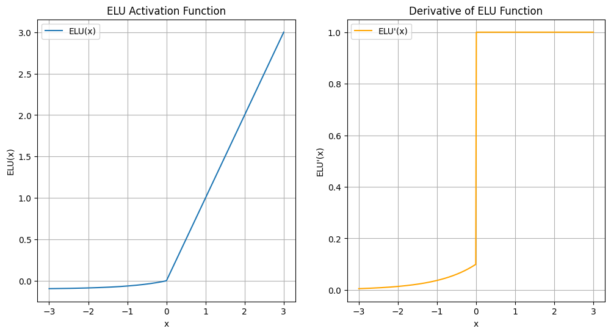

```python
import numpy as np
import matplotlib.pyplot as plt

def elu(x, alpha=0.1):
    return np.where(x > 0, x, alpha * (np.exp(x) - 1))

def elu_derivative(x, alpha=0.1):
    return np.where(x > 0, 1, alpha * np.exp(x))

x = np.linspace(-3, 3, 400)
y_elu = elu(x)
y_elu_deriv = elu_derivative(x)

plt.figure(figsize=(12, 6))

plt.subplot(1, 2, 1)
plt.plot(x, y_elu, label="ELU(x)")
plt.title("ELU Activation Function")
plt.xlabel("x")
plt.ylabel("ELU(x)")
plt.grid(True)
plt.legend()

plt.subplot(1, 2, 2)
plt.plot(x, y_elu_deriv, label="ELU'(x)", color='orange')
plt.title("Derivative of ELU Function")
plt.xlabel("x")
plt.ylabel("ELU'(x)")
plt.grid(True)
plt.legend()

plt.show()
```

#### (b) Gaussian Error Linear Unit (GELU)

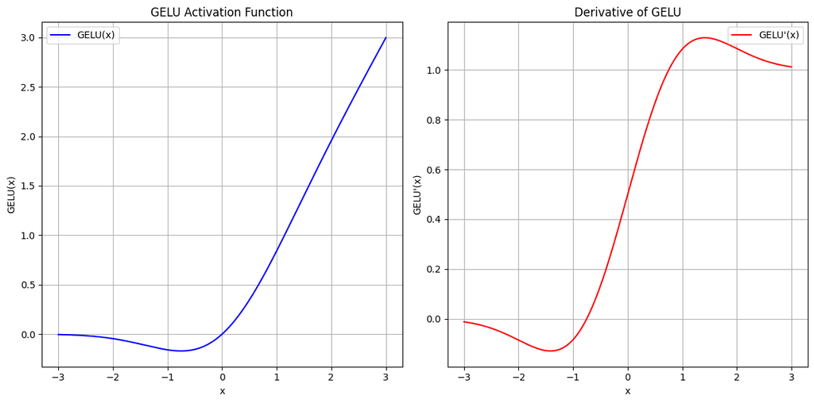

```python
from scipy.stats import norm
import numpy as np
import matplotlib.pyplot as plt

def gelu(x):
    return x * norm.cdf(x)

# Derivative of GELU
def gelu_derivative(x):
    pdf = norm.pdf(x)  # Probability density function (PDF) of the normal distribution
    cdf = norm.cdf(x)  # Cumulative distribution function (CDF) of the normal distribution
    return cdf + x * pdf

# Values for plotting
x_vals = np.linspace(-3, 3, 400)
y_gelu = gelu(x_vals)
y_deriv = gelu_derivative(x_vals)

# Plot GELU and its derivative
plt.figure(figsize=(12, 6))

# Plot GELU function
plt.subplot(1, 2, 1)
plt.plot(x_vals, y_gelu, label="GELU(x)", color='blue')
plt.title("GELU Activation Function")
plt.xlabel("x")
plt.ylabel("GELU(x)")
plt.grid(True)
plt.legend()

# Plot GELU derivative
plt.subplot(1, 2, 2)
plt.plot(x_vals, y_deriv, label="GELU'(x)", color='red')
plt.title("Derivative of GELU")
plt.xlabel("x")
plt.ylabel("GELU'(x)")
plt.grid(True)
plt.legend()

plt.tight_layout()
plt.show()
```

#### **Question 1.2:** **Assume that we feed a data point $x$ with a ground-truth label $y=2$ to the feed-forward neural network with the `ReLU activation` function as shown in the following figure**

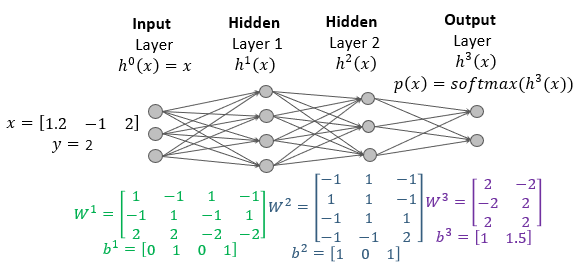

**(a)** What is the numerical value of the latent presentation $h^1(x)$?

[1 point]

**(b)** What is the numerical value of the latent presentation $h^2(x)$?

[1 point]

**(c)** What is the numerical value of the logit $h^3(x)$?

[1 point]

**(d)** What is the corresonding prediction probabilities $p(x)$?

[1 point]

**(e)** What is the predicted label $\widehat{y}$? Is it a correct and an incorect prediction? Remind that $y=2$.

[1 point]

**(f)** What is the cross-entropy loss caused by the feed-forward neural network at $(x,y)$? Remind that $y=2$.

[1 point]

**(g)** Why is the cross-entropy loss caused by the feed-forward neural network at $(x,y)$ (i.e., $\text{CE}(1_y, p(x))$) always non-negative? When does this $\text{CE}(1_y, p(x))$ loss get the value $0$? Note that you need to answer this question for a general pair $(x,y)$ and a general feed-forward neural network with, for example $M=4$ classes?

[1 point]

*You must show both formulas and numerical results for earning full mark. Although it is optional, it is great if you show your PyTorch code for your computation.*

```python
import torch
import torch.nn.functional as F

# Define the input vector and parameters
x = torch.tensor([1.2, -1, 2], dtype=torch.float32)  # Input
W1 = torch.tensor([[1, -1, 1, -1],
                   [-1, 1, -1, 1],
                   [2, 2, -2, -2]], dtype=torch.float32)  # Weight for layer 1
b1 = torch.tensor([0, 1, 0, 1], dtype=torch.float32)  # Bias for layer 1

W2 = torch.tensor([[-1, 1, -1],
                   [1, 1, -1],
                   [-1, 1, 1],
                   [-1, -1, 2]], dtype=torch.float32)  # Weight for layer 2
b2 = torch.tensor([1, 0, 1], dtype=torch.float32)  # Bias for layer 2

W3 = torch.tensor([[2, -2],
                   [-2, 2],
                   [2, 2]], dtype=torch.float32)  # Weight for layer 3
b3 = torch.tensor([1, 1.5], dtype=torch.float32)  # Bias for layer 3

# Forward pass
# Layer 1
h1 = F.relu(x @ W1 + b1)
# Layer 2
h2 = F.relu(h1 @ W2 + b2)
# Layer 3
h3 = h2 @ W3 + b3

# Softmax activation for output
p_x = F.softmax(h3, dim=0)

# Convert target to tensor
y = torch.tensor([1], dtype=torch.long)  # True label (as a batch with one sample, assuming class 1)

# Reshape logits to have the shape [1, num_classes]
h3 = h3.unsqueeze(0)  # Shape [1, 2]

# Verify shapes
print("Shape of h3:", h3.shape)
print("Shape of y:", y.shape)

# Predicted label (1-indexed)
predicted_label = torch.argmax(p_x).item()

# Loss calculation
loss = F.cross_entropy(h3, y)

# Print results
print("a) Latent representation h1(x):", h1)
print("b) Latent representation h2(x):", h2)
print("c) Logit h3(x):", h3)
print("d) Prediction probabilities p(x):", p_x)
print("e) Predicted label ŷ:", predicted_label + 1) # Since the predicted label is 1-indexed
print("e) Is the prediction correct?", "Yes" if predicted_label == y.item() else "No")
print("f) Cross-entropy loss:", loss.item())
print("g) Cross-entropy loss explanation: \n"
      "The cross-entropy loss is always non-negative because it measures the difference between the true label distribution and the predicted probability distribution. "
      "The loss is zero when the predicted probability for the true class is 1 (i.e., the predicted class matches the true class with certainty).")
```

```
Shape of h3: torch.Size([1, 2])
Shape of y: torch.Size([1])
a) Latent representation h1(x): tensor([6.2000, 2.8000, 0.0000, 0.0000])
b) Latent representation h2(x): tensor([0., 9., 0.])
c) Logit h3(x): tensor([[-17.0000,  19.5000]])
d) Prediction probabilities p(x): tensor([1.4069e-16, 1.0000e+00])
e) Predicted label ŷ: 2
e) Is the prediction correct? Yes
f) Cross-entropy loss: 0.0
g) Cross-entropy loss explanation:
The cross-entropy loss is always non-negative because it measures the difference between the true label distribution and the predicted probability distribution. The loss is zero when the predicted probability for the true class is 1 (i.e., the predicted class matches the true class with certainty).
```

#### **Question 1.3:**

For **Question 1.3**, you have two options:

- **(1)** *perform the forward, backward propagation, and SGD update for `one mini-batch`* (**10 points**), or
- **(2)** *manually implement a feed-forward neural network* that can work on real tabular datasets (**20 points**).

You can choose either **(1)** or **(2)** to proceed.

### **Option 1**

[Total marks for this option: 10 points]

**Assume that we are constructing a multilayered feed-forward neural network for a classification problem with three classes where the model parameters will be generated randomly using your student ID. The architecture of this network is $3 (Input)\rightarrow 5(ELU) \rightarrow 3(Output)$ as shown in the following figure. Note that the ELU has the same formula as the one in Q1.1.**

We feed a batch $X$ with the labels $Y$ as shown in the figure. Answer the following questions.

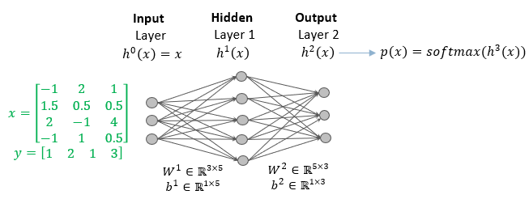

**You need to show both formulas, numerical results, and your PyTorch code for your computation for earning full marks.**

```python
import torch
student_id = 1234           #insert your student id here for example 1234
torch.manual_seed(student_id)
```

```
<torch._C.Generator at 0x7dc439f98810>
```

```python
#Code to generate random matrices and biases for W1, b1, W2, b2
```

**Forward propagation**

**(a)** What is the value of $\bar{h}^{1}(x)$ (the pre-activation values of $h^1$)?

[0.5 point]

```python
#Show your code
```

**(b)** What is the value of $h^{1}(x)$?

[0.5 point]

```python
#Show your code
```

**(c)** What is the predicted value $\widehat{y}$?

[0.5 point]

```python
#Show your code
```

(d) Suppose that we use the cross-entropy (CE) loss. What is the value of the CE loss $l$ incurred by the mini-batch?

[0.5 point]

```python
#Show your code
```

**Backward propagation**

**(e)** What are the derivatives $\frac{\partial l}{\partial h^{2}},\frac{\partial l}{\partial W^{2}}$, and $\frac{\partial l}{\partial b^{2}}$?

[3 points]

```python
#Show your code
```

**(f)** What are the derivatives $\frac{\partial l}{\partial h^{1}}, \frac{\partial l}{\partial \bar{h}^{1}},\frac{\partial l}{\partial W^{1}}$, and $\frac{\partial l}{\partial b^{1}}$?

[3 points]

```python
#Show your code
```

**SGD update**

**(g)** Assume that we use SGD with learning rate $\eta=0.01$ to update the model parameters. What are the values of $W^2, b^2$ and $W^1, b^1$ after updating?

[2 points]

```python
#Show your code
```

### **Option 2**

[Total marks for this option: 20 points]

```python
import torch
from torch.utils.data import DataLoader
from torchvision import datasets, transforms
```

**In Option 2, you need to implement a feed-forward NN manually using PyTorch and auto-differentiation of PyTorch. We then manually train the model on the MNIST dataset**.

We first download the `MNIST` dataset and preprocess it.

```python
transform = transforms.Compose([
    transforms.ToTensor(),  # Convert the image to a tensor with shape [C, H, W]
    transforms.Normalize((0.5,), (0.5,)),  # Normalize to [-1, 1]
    transforms.Lambda(lambda x: x.view(28*28)) # Flatten the tensor to shape [-1,HW]
])

# Load the MNIST dataset
train_dataset = datasets.MNIST(root='./data', train=True, download=True, transform=transform)
test_dataset = datasets.MNIST(root='./data', train=False, download=True, transform=transform)

train_data, train_labels = train_dataset.data, train_dataset.targets
test_data, test_labels = test_dataset.data, test_dataset.targets
print(train_data.shape, train_labels.shape)
print(test_data.shape, test_labels.shape)
```

[output not shown]

[output not shown]

[output not shown]

[output not shown]

```
Extracting ./data/MNIST/raw/t10k-labels-idx1-ubyte.gz to ./data/MNIST/raw

torch.Size([60000, 28, 28]) torch.Size([60000])
torch.Size([10000, 28, 28]) torch.Size([10000])
```

Each data point has dimension `[28,28]`. We need to flatten it to a vector to input to our FFN.

```python
train_dataset.data = train_data.data.view(-1, 28*28)
test_dataset.data = test_data.data.view(-1, 28*28)

train_data, train_labels = train_dataset.data, train_dataset.targets
test_data, test_labels = test_dataset.data, test_dataset.targets
print(train_data.shape, train_labels.shape)
print(test_data.shape, test_labels.shape)
```

```
torch.Size([60000, 784]) torch.Size([60000])
torch.Size([10000, 784]) torch.Size([10000])
```

```python
train_loader = DataLoader(dataset=train_dataset, batch_size=64, shuffle=True)
test_loader = DataLoader(dataset=test_dataset, batch_size=64, shuffle=False)
```

**Develop the feed-forward neural networks**

**(a)** You need to develop the class `MyLinear` with the following skeleton

[3 points]

```python
class MyLinear(torch.nn.Module):
  def __init__(self, input_size, output_size):
    """
    input_size: the size of the input
    output_size: the size of the output
    """
    super().__init__()
    #Your code here
    self.weights = torch.nn.Parameter(torch.randn(input_size, output_size) * 0.01)
    self.bias = torch.nn.Parameter(torch.zeros(output_size))

  #forward propagation
  def forward(self, x): #x is a mini-batch
    #Your code here
    return x @ self.weights + self.bias
```

**(b)** You need to develop the class `MyFFN` with the following skeleton

[7 points]

```python
import torch

class MyFFN(torch.nn.Module):
    def __init__(self, input_size, num_classes, hidden_sizes, act=torch.nn.ReLU()):
        """
        input_size: the size of the input
        num_classes: the number of classes
        act is the activation function
        hidden_sizes is the list of hidden sizes
        """
        super(MyFFN, self).__init__()
        self.input_size = input_size
        self.num_classes = num_classes
        self.act = act
        self.hidden_sizes = hidden_sizes
        self.num_layers = len(hidden_sizes) + 1  # Hidden layers + output layer
        self.create_FFN()

        # For momentum
        self.velocities = [torch.zeros_like(p) for p in self.parameters()]

        # For Adagrad
        self.cache = [torch.zeros_like(p) for p in self.parameters()]

    def create_FFN(self):
        """
        This function creates the feed-forward neural network
        We stack many MyLinear layers
        """
        layers = []
        hidden_sizes = [self.input_size] + self.hidden_sizes + [self.num_classes]

        for i in range(len(hidden_sizes) - 1):
            layers.append(MyLinear(hidden_sizes[i], hidden_sizes[i + 1]))

        self.layers = torch.nn.ModuleList(layers)

    def forward(self, x):
        """
        Implements the forward propagation of the batch x
        """
        for i in range(self.num_layers - 1):  # Apply hidden layers
            x = self.layers[i](x)
            x = self.act(x)  # Activation after every hidden layer

        x = self.layers[-1](x)  # Final output layer without activation
        return x

    def compute_loss(self, x, y):
        """
        Computes the cross-entropy loss
        """
        logits = self.forward(x)
        loss = torch.nn.CrossEntropyLoss()(logits, y)
        return loss

    def update_SGD(self, x, y, learning_rate=0.01):
        """
        Updates the model parameters using SGD
        """
        loss = self.compute_loss(x, y)
        loss.backward()

        with torch.no_grad():
            for param in self.parameters():
                param -= learning_rate * param.grad

        self.zero_grad()

    def update_SGDwithMomentum(self, x, y, learning_rate=0.01, momentum=0.9):
        """
        Updates the model parameters using SGD with momentum
        """
        loss = self.compute_loss(x, y)
        loss.backward()

        with torch.no_grad():
            for i, param in enumerate(self.parameters()):
                # Update the velocity: v = momentum * v - learning_rate * grad
                self.velocities[i] = momentum * self.velocities[i] - learning_rate * param.grad
                # Update the parameters: p = p + v
                param += self.velocities[i]

        self.zero_grad()

    def update_AdaGrad(self, x, y, learning_rate=0.01, epsilon=1e-8):
        """
        Updates the model parameters using AdaGrad
        """
        loss = self.compute_loss(x, y)
        loss.backward()

        with torch.no_grad():
            for i, param in enumerate(self.parameters()):
                # Update the cache: cache += grad^2
                self.cache[i] += param.grad ** 2
                # Update the parameters: p -= learning_rate * grad / (sqrt(cache) + epsilon)
                param -= learning_rate * param.grad / (torch.sqrt(self.cache[i]) + epsilon)

        self.zero_grad()
```

```python
myFFN = MyFFN(input_size = 28*28, num_classes = 26, hidden_sizes = [100, 100], act = torch.nn.ReLU())
myFFN.create_FFN()
print(myFFN)
```

```
MyFFN(
  (act): ReLU()
  (layers): ModuleList(
    (0-2): 3 x MyLinear()
  )
)
```

**(c)** Write the code to evaluate the accuracy of the current `myFFN` model on a data loader (e.g., train_loader or test_loader).

[2.5 points]

```python
def compute_acc(model, data_loader):
  """
  This function computes the accuracy of the model on a data loader
  """
  #Your code here
  correct = 0
  total = 0
  with torch.no_grad():
      for x, y in data_loader:
          outputs = model(x)
          _, predicted = torch.max(outputs.data, 1)
          total += y.size(0)
          correct += (predicted == y).sum().item()
  return correct / total
```

**(c)** Write the code to evaluate the loss of the current `myFFN` model on a data loader (e.g., train_loader or test_loader).

[2.5 points]

```python
def compute_loss(model, data_loader):
  """
  This function computes the loss of the model on a data loader
  """
  #Your code here
  total_loss = 0.0
  with torch.no_grad():
      for x, y in data_loader:
          loss = model.compute_loss(x, y)
          total_loss += loss.item()
  return total_loss / len(data_loader)
```

Train on the `MNIST` data with 50 epochs using `updateSGD`.

```python
ffn_sgd = MyFFN(input_size = 28*28, num_classes = 26, hidden_sizes = [100, 100], act = torch.nn.ReLU())
ffn_sgd.create_FFN()

num_epochs = 50
for epoch in range(num_epochs):
    for i, (x, y) in enumerate(train_loader):
      ffn_sgd.update_SGD(x, y, learning_rate = 0.01)
    train_acc = compute_acc(ffn_sgd, train_loader)
    train_loss = compute_loss(ffn_sgd, train_loader)
    test_acc = compute_acc(ffn_sgd, test_loader)
    test_loss = compute_loss(ffn_sgd, test_loader)
    print(f"Epoch {epoch+1}/{num_epochs}, Train Loss: {train_loss:.4f}, Train Acc: {train_acc*100:.2f}%, Test Loss: {test_loss:.4f}, Test Acc: {test_acc*100:.2f}%")
```

[output not shown]

**(d)** Implement the function `updateSGDMomentum` in the class and train the model with this optimizer in `50` epochs. You can update the corresponding function in the `MyFNN` class.

[2.5 points]

```python
ffn_sgdmomentum = MyFFN(input_size = 28*28, num_classes = 26, hidden_sizes = [100, 100], act = torch.nn.ReLU())
ffn_sgdmomentum.create_FFN()

#Your code here
for epoch in range(num_epochs):
    for i, (x, y) in enumerate(train_loader):
        ffn_sgdmomentum.update_SGDwithMomentum(x, y, learning_rate=0.01)
    train_acc = compute_acc(ffn_sgdmomentum, train_loader)
    train_loss = compute_loss(ffn_sgdmomentum, train_loader)
    test_acc = compute_acc(ffn_sgdmomentum, test_loader)
    test_loss = compute_loss(ffn_sgdmomentum, test_loader)
    print(f"Epoch {epoch+1}/{num_epochs}, Train Loss: {train_loss:.4f}, Train Acc: {train_acc*100:.2f}%, Test Loss: {test_loss:.4f}, Test Acc: {test_acc*100:.2f}%")
```

[output not shown]

**(e)** Implement the function `updateAdagrad` in the class and train the model with this optimizer in `50` epochs. You can update the corresponding function in the `MyFNN` class.

[2.5 points]

```python
ffn_adagrad = MyFFN(input_size = 28*28, num_classes = 26, hidden_sizes = [100, 100], act = torch.nn.ReLU())
ffn_adagrad.create_FFN()

#Your code here
for epoch in range(num_epochs):
    for i, (x, y) in enumerate(train_loader):
        ffn_adagrad.update_AdaGrad(x, y, learning_rate=0.01)
    train_acc = compute_acc(ffn_adagrad, train_loader)
    train_loss = compute_loss(ffn_adagrad, train_loader)
    test_acc = compute_acc(ffn_adagrad, test_loader)
    test_loss = compute_loss(ffn_adagrad, test_loader)
    print(f"Epoch {epoch+1}/{num_epochs}, Train Loss: {train_loss:.4f}, Train Acc: {train_acc*100:.2f}%, Test Loss: {test_loss:.4f}, Test Acc: {test_acc*100:.2f}%")
```

[output not shown]

## Part 2: Deep Neural Networks (DNN)

[Total marks for this part: 25 points]

The second part of this assignment is to demonstrate your basis knowledge in deep learning that you have acquired from the lectures and tutorials materials. Most of the contents in this assignment are drawn from **the tutorials covered from weeks 1 to 2**. Going through these materials before attempting this assignment is highly recommended.

In the second part of this assignment, you are going to work with the FashionMNIST dataset for image recognition task. It has the exact same format as MNIST (70,000 grayscale images of 28 × 28 pixels each with 10 classes), but the images represent fashion items rather than handwritten digits, so each class is more diverse, and the problem is significantly more challenging than MNIST.

```python
import torch
from torch.utils.data import DataLoader
from torchvision import datasets, transforms

torch.manual_seed(1234)
```

```
<torch._C.Generator at 0x7fbf34210f10>
```

**Load the Fashion MNIST using `torchvision`**

```python
transform = transforms.Compose([transforms.ToTensor(), transforms.Normalize((0.5,), (0.5,))])

train_dataset_orgin = datasets.FashionMNIST(root='./data', train=True, download=True, transform=transform)
test_dataset = datasets.FashionMNIST(root='./data', train=False, download=True, transform=transform)

print(train_dataset_orgin.data.shape, train_dataset_orgin.targets.shape)
print(test_dataset.data.shape, test_dataset.targets.shape)

train_dataset_orgin.data = train_dataset_orgin.data.view(-1, 28*28)
test_dataset.data = test_dataset.data.view(-1, 28*28)

print(train_dataset_orgin.data.shape, train_dataset_orgin.targets.shape)
print(test_dataset.data.shape, test_dataset.targets.shape)

N = len(train_dataset_orgin)
print(f"Number of training samples: {N}")
N_train = int(0.9*N)
N_val = N - N_train
print(f"Number of training samples: {N_train}")
print(f"Number of validation samples: {N_val}")

train_dataset, val_dataset = torch.utils.data.random_split(train_dataset_orgin, [N_train, N_val])


train_loader = DataLoader(dataset=train_dataset, batch_size=64, shuffle=True)
val_loader = DataLoader(dataset=val_dataset, batch_size=64, shuffle=False)
test_loader = DataLoader(dataset=test_dataset, batch_size=1000, shuffle=False)
```

```
Downloading http://fashion-mnist.s3-website.eu-central-1.amazonaws.com/train-images-idx3-ubyte.gz
Downloading http://fashion-mnist.s3-website.eu-central-1.amazonaws.com/train-images-idx3-ubyte.gz to ./data/FashionMNIST/raw/train-images-idx3-ubyte.gz
```

```
Extracting ./data/FashionMNIST/raw/train-images-idx3-ubyte.gz to ./data/FashionMNIST/raw

Downloading http://fashion-mnist.s3-website.eu-central-1.amazonaws.com/train-labels-idx1-ubyte.gz
Downloading http://fashion-mnist.s3-website.eu-central-1.amazonaws.com/train-labels-idx1-ubyte.gz to ./data/FashionMNIST/raw/train-labels-idx1-ubyte.gz
```

```
Extracting ./data/FashionMNIST/raw/train-labels-idx1-ubyte.gz to ./data/FashionMNIST/raw

Downloading http://fashion-mnist.s3-website.eu-central-1.amazonaws.com/t10k-images-idx3-ubyte.gz
Downloading http://fashion-mnist.s3-website.eu-central-1.amazonaws.com/t10k-images-idx3-ubyte.gz to ./data/FashionMNIST/raw/t10k-images-idx3-ubyte.gz
```

```
Extracting ./data/FashionMNIST/raw/t10k-images-idx3-ubyte.gz to ./data/FashionMNIST/raw

Downloading http://fashion-mnist.s3-website.eu-central-1.amazonaws.com/t10k-labels-idx1-ubyte.gz
Downloading http://fashion-mnist.s3-website.eu-central-1.amazonaws.com/t10k-labels-idx1-ubyte.gz to ./data/FashionMNIST/raw/t10k-labels-idx1-ubyte.gz
```

```
Extracting ./data/FashionMNIST/raw/t10k-labels-idx1-ubyte.gz to ./data/FashionMNIST/raw

torch.Size([60000, 28, 28]) torch.Size([60000])
torch.Size([10000, 28, 28]) torch.Size([10000])
torch.Size([60000, 784]) torch.Size([60000])
torch.Size([10000, 784]) torch.Size([10000])
Number of training samples: 60000
Number of training samples: 54000
Number of validation samples: 6000
```

#### **Question 2.1:** Write the code to visualize a mini-batch in `train_loader` including its images and labels.

[5 points]

[figure not shown]

```python
#Your code here
import matplotlib.pyplot as plt
import numpy as np

# Function to display a batch of images with labels
def show_batch(images, labels, classes):
    # Create a grid of 8x8 images
    fig, ax = plt.subplots(8, 8, figsize=(10, 10))
    ax = ax.flatten()

    # Display each image in the grid
    for i in range(64):
        img = images[i].view(28, 28)  # Reshape the image back to 28x28
        ax[i].imshow(img, cmap='gray')
        ax[i].axis('off')
        ax[i].set_title(classes[labels[i].item()])

    plt.tight_layout()
    plt.show()

# Load a mini-batch of images and labels
dataiter = iter(train_loader)
images, labels = next(dataiter)

# Define the classes for FashionMNIST
classes = ['T-shirt/top', 'Trouser', 'Pullover', 'Dress', 'Coat',
           'Sandal', 'Shirt', 'Sneaker', 'Bag', 'Ankle boot']

# Visualize the mini-batch
show_batch(images, labels, classes)
```

#### **Question 2.2:** Write the code for the feed-forward neural net using PyTorch

[5 points]

We now develop a feed-forward neural network with the architecture $784 \rightarrow 40(ReLU) \rightarrow 30(ReLU) \rightarrow 10(softmax)$. You can choose your own way to implement your network and an optimizer of interest. You should train model in $50$ epochs and evaluate the trained model on the test set.

```python
#Your code here
import torch
import torch.nn as nn
import torch.optim as optim
from torch.utils.data import DataLoader
from torchvision import datasets, transforms
from torchsummary import summary


class FeedForwardNN(nn.Module):
    def __init__(self, input_size=784, num_classes=10):
        super(FeedForwardNN, self).__init__()
        self.fc1 = nn.Linear(input_size, 40)  # Input layer to first hidden layer
        self.fc2 = nn.Linear(40, 30)          # First hidden layer to second hidden layer
        self.fc3 = nn.Linear(30, num_classes) # Second hidden layer to output layer

    def forward(self, x):
        x = torch.relu(self.fc1(x))
        x = torch.relu(self.fc2(x))
        x = self.fc3(x)  # No softmax here because we'll use CrossEntropyLoss
        return x

device = torch.device("cuda:0" if torch.cuda.is_available() else "cpu")
model = FeedForwardNN().to(device)
summary(model, (1, 784))

learning_rate = 0.0004
loss_fn = nn.CrossEntropyLoss()
optimizer = torch.optim.Adam(model.parameters(), lr=learning_rate)

def compute_loss(model, loss_fn, loader, device):
    loss = 0.0
    model.eval()
    with torch.no_grad():
        for (batchX, batchY) in loader:
            batchX, batchY = batchX.to(device), batchY.to(device)
            outputs = model(batchX.view(-1, 28*28))  # Flatten the images
            loss += loss_fn(outputs, batchY)
    return loss.item() / len(loader)

def compute_acc(model, loader, device):
    corrects = 0
    totals = 0
    model.eval()
    with torch.no_grad():
        for (batchX, batchY) in loader:
            batchX, batchY = batchX.to(device), batchY.to(device)
            outputs = model(batchX.view(-1, 28*28))
            _, predicted = torch.max(outputs.data, 1)
            totals += batchY.size(0)
            corrects += (predicted == batchY).sum().item()
    return corrects / totals

transform = transforms.Compose([transforms.ToTensor(), transforms.Normalize((0.5,), (0.5,))])

train_dataset = datasets.FashionMNIST(root='./data', train=True, transform=transform, download=True)
test_dataset = datasets.FashionMNIST(root='./data', train=False, transform=transform)

train_loader = DataLoader(dataset=train_dataset, batch_size=64, shuffle=True)
test_loader = DataLoader(dataset=test_dataset, batch_size=64, shuffle=False)
num_epochs = 50
history = {'train_loss': [], 'train_acc': [], 'val_loss': [], 'val_acc': []}

for epoch in range(num_epochs):
    model.train()
    running_loss = 0.0

    for i, (X, y) in enumerate(train_loader):
        X, y = X.to(device), y.to(device)

        # Forward pass
        outputs = model(X.view(-1, 28*28))  # Flatten the images
        loss = loss_fn(outputs, y)

        # Backward and optimize
        optimizer.zero_grad()
        loss.backward()
        optimizer.step()

        running_loss += loss.item()

    # Compute loss and accuracy for training and validation sets
    train_loss = running_loss / len(train_loader)
    train_acc = compute_acc(model, train_loader, device)
    val_loss = compute_loss(model, loss_fn, test_loader, device)
    val_acc = compute_acc(model, test_loader, device)

    # Print the epoch results
    print(f"Epoch {epoch+1}/{num_epochs}")
    print(f"Train Loss: {train_loss:.4f} | Train Acc: {train_acc*100:.2f}%")
    print(f"Val Loss: {val_loss:.4f} | Val Acc: {val_acc*100:.2f}%")

    # Store history for plotting
    history['train_loss'].append(train_loss)
    history['train_acc'].append(train_acc)
    history['val_loss'].append(val_loss)
    history['val_acc'].append(val_acc)
test_acc = compute_acc(model, test_loader, device)
print(f"Final Test Accuracy: {test_acc*100:.2f}%")
```

[output not shown]

[output cut: 62 more lines]

```
Train Loss: 0.2061 | Train Acc: 93.06%
Val Loss: 0.3652 | Val Acc: 88.21%
Train Loss: 0.2029 | Train Acc: 92.71%
Val Loss: 0.3811 | Val Acc: 87.74%
Train Loss: 0.2032 | Train Acc: 93.16%
Val Loss: 0.3671 | Val Acc: 88.08%
Train Loss: 0.2009 | Train Acc: 92.80%
Val Loss: 0.3801 | Val Acc: 87.73%
Train Loss: 0.1992 | Train Acc: 93.39%
Val Loss: 0.3675 | Val Acc: 88.03%
Train Loss: 0.1982 | Train Acc: 93.04%
Val Loss: 0.3803 | Val Acc: 87.55%
Train Loss: 0.1950 | Train Acc: 93.36%
Val Loss: 0.3747 | Val Acc: 87.94%
Final Test Accuracy: 87.94%
```

#### **Question 2.3:** Tuning hyper-parameters with grid search

[5 points]

Assume that you need to tune the number of neurons on the first and second hidden layers $n_1 \in \{20, 40\}$, $n_2 \in \{20, 40\}$ and the used activation function $act \in \{sigmoid, tanh, relu\}$. The network has the architecture pattern $784 \rightarrow n_1 (act) \rightarrow n_2(act) \rightarrow 10(softmax)$ where $n_1, n_2$, and $act$ are in their grides. Write the code to tune the hyper-parameters $n_1, n_2$, and $act$. Note that you can freely choose the optimizer and learning rate of interest for this task.

```python
#Your code here
class GridSearchNN(nn.Module):
    def __init__(self, n1, n2, act_fn):
        super(GridSearchNN, self).__init__()
        self.fc1 = nn.Linear(784, n1)
        self.fc2 = nn.Linear(n1, n2)
        self.fc3 = nn.Linear(n2, 10)

        # Choose the activation function
        if act_fn == 'relu':
            self.act = nn.ReLU()
        elif act_fn == 'sigmoid':
            self.act = nn.Sigmoid()
        elif act_fn == 'tanh':
            self.act = nn.Tanh()

    def forward(self, x):
        x = self.act(self.fc1(x))
        x = self.act(self.fc2(x))
        x = self.fc3(x)
        return x

device = torch.device("cuda:0" if torch.cuda.is_available() else "cpu")

n1_values = [20, 40]
n2_values = [20, 40]
activation_functions = ['sigmoid', 'tanh', 'relu']

best_val_acc = 0.0
best_params = None

for n1 in n1_values:
    for n2 in n2_values:
        for act in activation_functions:
            # Initialize the model with the current set of hyperparameters
            model = GridSearchNN(n1, n2, act).to(device)

            # Define the optimizer and loss function
            optimizer = torch.optim.Adam(model.parameters(), lr=0.0004)
            loss_fn = nn.CrossEntropyLoss()

            # Train the model for a fixed number of epochs
            num_epochs = 10
            for epoch in range(num_epochs):
                model.train()
                for i, (X, y) in enumerate(train_loader):
                    X, y = X.to(device), y.to(device)
                    outputs = model(X.view(-1, 28*28))
                    loss = loss_fn(outputs, y)

                    optimizer.zero_grad()
                    loss.backward()
                    optimizer.step()

            # Evaluate on the validation set
            val_acc = compute_acc(model, test_loader, device)
            print(f'n1={n1}, n2={n2}, act={act} | Val Acc: {val_acc*100:.2f}%')

            # Check if this combination is the best
            if val_acc > best_val_acc:
                best_val_acc = val_acc
                best_params = (n1, n2, act)

print(f'Best Validation Accuracy: {best_val_acc*100:.2f}% with n1={best_params[0]}, n2={best_params[1]}, act={best_params[2]}')
```

```
n1=20, n2=20, act=sigmoid | Val Acc: 84.27%
n1=20, n2=20, act=tanh | Val Acc: 86.51%
n1=20, n2=20, act=relu | Val Acc: 85.19%
n1=20, n2=40, act=sigmoid | Val Acc: 85.37%
n1=20, n2=40, act=tanh | Val Acc: 85.96%
n1=20, n2=40, act=relu | Val Acc: 86.14%
n1=40, n2=20, act=sigmoid | Val Acc: 85.12%
n1=40, n2=20, act=tanh | Val Acc: 87.00%
n1=40, n2=20, act=relu | Val Acc: 86.79%
n1=40, n2=40, act=sigmoid | Val Acc: 85.86%
n1=40, n2=40, act=tanh | Val Acc: 87.00%
n1=40, n2=40, act=relu | Val Acc: 87.11%
Best Validation Accuracy: 87.11% with n1=40, n2=40, act=relu
```

#### **Question 2.4:** Implement the loss with the form: $loss(p,y)=CE(1_{y},p)+\lambda H(p)$ where $H(p)=-\sum_{i=1}^{M}p_{i}\log p_{i}$ is the entropy of $p$, $p$ is the prediction probabilities of a data point $x$ with the ground-truth label $y$, $1_y$ is an one-hot label, and $\lambda >0$ is a trade-off parameter. Set $\lambda = 0.1$ to train a model.

[5 points]

```python
#Your code here
import torch
import torch.nn as nn
import torch.nn.functional as F

class CustomLoss(nn.Module):
    def __init__(self, lambda_param=0.1):
        super(CustomLoss, self).__init__()
        self.lambda_param = lambda_param
        self.ce_loss = nn.CrossEntropyLoss()

    def forward(self, predictions, targets):
        # Cross-Entropy Loss
        ce_loss = self.ce_loss(predictions, targets)

        # Entropy H(p)
        p = F.softmax(predictions, dim=1)
        entropy = -torch.sum(p * torch.log(p + 1e-9), dim=1).mean()

        # Custom loss: CE + lambda * H(p)
        loss = ce_loss + self.lambda_param * entropy
        return loss

lambda_param = 0.1
criterion = CustomLoss(lambda_param=lambda_param)

# Best architecture found in Question 2.3
model = GridSearchNN(40, 40, 'relu').to(device)

# Define the optimizer
optimizer = torch.optim.Adam(model.parameters(), lr=0.0004)

# Define the custom loss function
criterion = CustomLoss(lambda_param=0.1)

# Training loop
num_epochs = 20
for epoch in range(num_epochs):
    model.train()
    for X, y in train_loader:
        X, y = X.to(device), y.to(device)

        # Forward pass
        outputs = model(X.view(-1, 28*28))

        # Compute loss
        loss = criterion(outputs, y)

        # Backward pass and optimization
        optimizer.zero_grad()
        loss.backward()
        optimizer.step()

    # Validation accuracy
    val_acc = compute_acc(model, test_loader, device)
    print(f"Epoch {epoch+1}/{num_epochs}, Loss: {loss.item():.4f}, Validation Accuracy: {val_acc*100:.2f}%")
```

[output not shown]

#### **Question 2.5:** Experimenting with **sharpness-aware minimization** technique

[5 points]

Sharpness-aware minimization (SAM) (i.e., [link for main paper](https://openreview.net/pdf?id=6Tm1mposlrM) from Google Deepmind) is a simple yet but efficient technique to improve the generalization ability of deep learning models on unseen data examples. In your research or your work, you might potentially use this idea. Your task is to read the paper and implement *Sharpness-aware minimization (SAM)*. Finally, you need to apply SAM to the best architecture found in **Question 2.3**.

```python
#Your code here
import torch
import torch.nn as nn
import torch.optim as optim

class SAM:
    def __init__(self, base_optimizer, model, rho=0.05):
        self.base_optimizer = base_optimizer
        self.model = model
        self.rho = rho
        self.param_groups = base_optimizer.param_groups

    def step(self, closure):
        # First forward-backward pass
        loss = closure()  # Compute gradients with original weights

        # Save original parameters
        with torch.no_grad():
            original_params = [param.clone() for param in self.model.parameters()]

        # Compute the perturbation and add it to the original parameters
        with torch.no_grad():
            for param in self.model.parameters():
                e_w = param.grad * self.rho / (param.grad.norm() + 1e-12)
                param.add_(e_w)  # Apply perturbation

        # Second forward-backward pass
        loss = closure()

        # Restore original parameters
        with torch.no_grad():
            for original_param, param in zip(original_params, self.model.parameters()):
                param.copy_(original_param)

        # Final update step
        self.base_optimizer.step()

        return loss

# Best architecture found in Question 2.3
model = GridSearchNN(n1=40, n2=40, act_fn='relu').to(device)

# Define the base optimizer
base_optimizer = optim.Adam(model.parameters(), lr=0.001)

# Wrap the base optimizer with SAM
sam_optimizer = SAM(base_optimizer, model)

# Loss function
criterion = nn.CrossEntropyLoss()

# Training loop with SAM
num_epochs = 10
for epoch in range(num_epochs):
    model.train()
    for X, y in train_loader:
        X, y = X.to(device), y.to(device)

        # Define the closure for SAM
        def closure():
            sam_optimizer.base_optimizer.zero_grad()  # Use the base optimizer's zero_grad
            outputs = model(X.view(-1, 28*28))
            loss = criterion(outputs, y)
            loss.backward()
            return loss

        # Perform SAM step
        loss = sam_optimizer.step(closure)

    # Validation accuracy
    val_acc = compute_acc(model, test_loader, device)
    print(f"Epoch {epoch+1}/{num_epochs}, Loss: {loss.item():.4f}, Validation Accuracy: {val_acc*100:.2f}%")
```

[output not shown]

## Part 3: Convolutional Neural Networks and Image Classification

[Total marks for this part: 45 points]

The third part of this assignment is to demonstrate your basis knowledge in deep learning that you have acquired from the lectures and tutorials materials. Most of the contents in this assignment are drawn from **the tutorials covered from weeks 3 to 6**. Going through these materials before attempting this assignment is highly recommended.

**The dataset used for this part is a specific dataset for this unit consisting of approximately $10,000$ images of $20$ classes of Animals, each of which has approximately 500 images. You can download the dataset at [download here](https://drive.google.com/file/d/1aEkxNWaD02Z8ZNvZzeMefUoY97C-3wTG/view?usp=drive_link) if you want to do your assignment on your machine.**

```python
import os
import requests
import tarfile
import time
from torchvision import datasets, transforms
from torch.utils.data import DataLoader, random_split
import torchvision.models as models
import torch.nn as nn
import torch
import PIL.Image
import pathlib
from torchsummary import summary
import matplotlib.pyplot as plt
%matplotlib inline
import numpy as np

# check if CUDA is available
train_on_gpu = torch.cuda.is_available()

if not train_on_gpu:
    print('CUDA is not available.  Training on CPU ...')
else:
    print('CUDA is available!  Training on GPU ...')

device = torch.device("cuda" if torch.cuda.is_available() else "cpu")
torch.manual_seed(1234)
```

```
CUDA is available!  Training on GPU ...
```

```
<torch._C.Generator at 0x7c77642608b0>
```

Download the dataset to the folder of this Google Colab.

```python
!gdown --fuzzy https://drive.google.com/file/d/1xum25Ja788a3ZPYmbVhZ_JddCxwv4tJz/view?usp=drive_link
# !gdown --fuzzy https://drive.google.com/file/d/1aEkxNWaD02Z8ZNvZzeMefUoY97C-3wTG/view?usp=drive_link
```

```
Downloading...
From (original): https://drive.google.com/uc?id=1xum25Ja788a3ZPYmbVhZ_JddCxwv4tJz
From (redirected): https://drive.google.com/uc?id=1xum25Ja788a3ZPYmbVhZ_JddCxwv4tJz&confirm=t&uuid=b5d542b5-d7f0-4716-b1f1-8ecbd45dc6c9
To: /content/Animals_Dataset.zip
100% 643M/643M [00:41<00:00, 15.6MB/s]
```

We unzip the dataset to the folder.

```python
# !unzip -q Animals_Dataset.zip -d Dataset
!unzip -q Animals_Dataset.zip
```

```python
data_dir = "./FIT5215_Dataset" # Changed this line, else the label of image will show all bird

# We resize the images to [3,64,64]
transform = transforms.Compose([transforms.Resize((64,64)),  #resises the image so it can be perfect for our model.
                                      transforms.RandomHorizontalFlip(), # FLips the image w.r.t horizontal axis
                                      #transforms.RandomRotation(4),     #Rotates the image to a specified angel
                                      #transforms.RandomAffine(0, shear=10, scale=(0.8,1.2)), #Performs actions like zooms, change shear angles.
                                      transforms.ColorJitter(brightness=0.2, contrast=0.2, saturation=0.2), # Set the color params
                                      transforms.ToTensor(), # convert the image to tensor so that it can work with torch
                                      transforms.Normalize((0.5, 0.5, 0.5), (0.5, 0.5, 0.5)),  # Normalize the images, each R,G,B value is normalized with mean=0.5 and std=0.5
                                      ])


# Load the dataset using torchvision.datasets.ImageFolder and apply transformations
dataset = datasets.ImageFolder(data_dir, transform=transform)

# Split the dataset into training and validation sets
train_size = int(0.9 * len(dataset))
valid_size = len(dataset) - train_size
train_dataset, val_dataset = random_split(dataset, [train_size, valid_size])

# Example of DataLoader creation for training and validation
train_loader = DataLoader(train_dataset, batch_size=32, shuffle=True)
val_loader = DataLoader(val_dataset, batch_size=32, shuffle=False)

print("Number of instance in train_set: %s" % len(train_dataset))
print("Number of instance in val_set: %s" % len(val_dataset))
```

```
Number of instance in train_set: 8519
Number of instance in val_set: 947
```

```python
class_names = ['bird', 'bottle', 'bread', 'butterfly', 'cake', 'cat', 'chicken', 'cow', 'dog', 'duck',
                  'elephant', 'fish', 'handgun', 'horse', 'lion', 'lipstick', 'seal', 'snake', 'spider', 'vase']
```

```python
# obtain one batch of training images
dataiter = iter(train_loader)
images, labels = next(dataiter)
images = images.numpy() # convert images to numpy for display
```

```python
import math

def imshow(img):
    img = img / 2 + 0.5  # unnormalize
    plt.imshow(np.transpose(img, (1, 2, 0)))  # convert from Tensor image

def visualize_data(images, categories, images_per_row = 8):
    class_names = ['bird', 'bottle', 'bread', 'butterfly', 'cake', 'cat', 'chicken', 'cow', 'dog', 'duck',
                  'elephant', 'fish', 'handgun', 'horse', 'lion', 'lipstick', 'seal', 'snake', 'spider', 'vase']
    n_images = len(images)
    n_rows = math.ceil(float(n_images)/images_per_row)
    fig = plt.figure(figsize=(1.5*images_per_row, 1.5*n_rows))
    fig.patch.set_facecolor('white')
    for i in range(n_images):
        plt.subplot(n_rows, images_per_row, i+1)
        plt.xticks([])
        plt.yticks([])
        imshow(images[i])
        class_index = categories[i]
        plt.xlabel(class_names[class_index])
    plt.show()
```

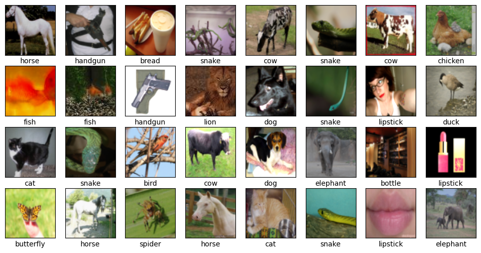

```python
visualize_data(images, labels)
```

**For questions 3.1 to 3.7, you'll need to write your own model in a way that makes it easy for you to experiment with different architectures and parameters. The goal is to be able to pass the parameters to initialize a new instance of `YourModel` to build different network architectures with different parameters. Below are descriptions of some parameters for `YourModel`:**

Here is the model confirguration of `YourCNN` if the `list_feature_maps = [16, 32, 64]` and `batch_norm = true`.

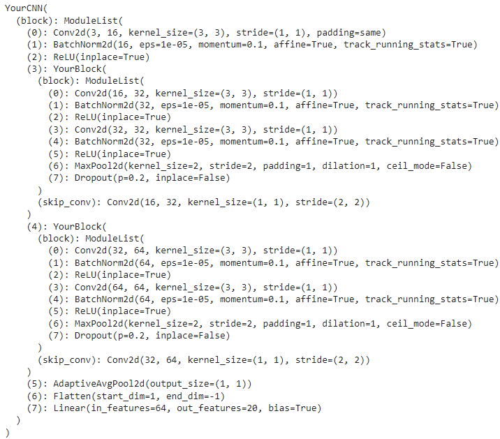

**Question 3.1:** **You need to implement the aforementioned CNN**.

**First, you need to implement the block of our CNN in the class `YourBlock`. You can ignore `use_skip` and `skip connection` for simplicity. However, you cannot earn full marks for this question.**

[6 points]

```python
import torch
import torch.nn as nn

class YourBlock(nn.Module):
    def __init__(self, in_feature_maps, out_feature_maps, drop_rate=0.2, batch_norm=True, use_skip=True):
        super(YourBlock, self).__init__()
        self.use_skip = use_skip

        layers = []
        layers.append(nn.Conv2d(in_feature_maps, out_feature_maps, kernel_size=3, stride=1, padding=1))
        if batch_norm:
            layers.append(nn.BatchNorm2d(out_feature_maps))
        layers.append(nn.ReLU(inplace=True))
        layers.append(nn.Conv2d(out_feature_maps, out_feature_maps, kernel_size=3, stride=1, padding=1))
        if batch_norm:
            layers.append(nn.BatchNorm2d(out_feature_maps))
        layers.append(nn.ReLU(inplace=True))
        layers.append(nn.MaxPool2d(kernel_size=2, stride=2))
        layers.append(nn.Dropout(p=drop_rate))

        if use_skip:
            self.skip_conv = nn.Conv2d(in_feature_maps, out_feature_maps, kernel_size=1, stride=2)
        else:
            self.skip_conv = None

        self.layer = nn.Sequential(*layers)

    def forward(self, x):
        identity = x if self.use_skip else None
        x = self.layer(x)

        if self.use_skip:
            identity = self.skip_conv(identity)
            x = x + identity

        return x
```

**Second, you need to use the above `YourBlock` to implement the class `YourCNN`**.

[6 points]

```python
class YourCNN(nn.Module):
    def __init__(self, list_feature_maps=[16, 32, 64], drop_rate=0.2, batch_norm=True, use_skip=True):
        super(YourCNN, self).__init__()

        layers = []
        layers.append(nn.Conv2d(3, list_feature_maps[0], kernel_size=3, stride=1, padding=1))
        if batch_norm:
            layers.append(nn.BatchNorm2d(list_feature_maps[0]))
        layers.append(nn.ReLU(inplace=True))

        for i in range(1, len(list_feature_maps)):
            layers.append(YourBlock(list_feature_maps[i - 1], list_feature_maps[i], drop_rate=drop_rate, batch_norm=batch_norm, use_skip=use_skip))

        layers.append(nn.AdaptiveAvgPool2d((1, 1)))
        layers.append(nn.Flatten())
        layers.append(nn.Linear(list_feature_maps[-1], 20))

        self.layers = nn.Sequential(*layers)

    def forward(self, x):
        return self.layers(x)
```

**We declare `my_cnn` from `YourCNN` as follows**.

```python
device = torch.device("cuda:0" if torch.cuda.is_available() else "cpu")
my_cnn = YourCNN(list_feature_maps = [16, 32, 64], use_skip = True)
my_cnn = my_cnn.to(device)
print(my_cnn)
```

```
YourCNN(
  (layers): Sequential(
    (0): Conv2d(3, 16, kernel_size=(3, 3), stride=(1, 1), padding=(1, 1))
    (1): BatchNorm2d(16, eps=1e-05, momentum=0.1, affine=True, track_running_stats=True)
    (2): ReLU(inplace=True)
    (3): YourBlock(
      (skip_conv): Conv2d(16, 32, kernel_size=(1, 1), stride=(2, 2))
      (layer): Sequential(
        (0): Conv2d(16, 32, kernel_size=(3, 3), stride=(1, 1), padding=(1, 1))
        (1): BatchNorm2d(32, eps=1e-05, momentum=0.1, affine=True, track_running_stats=True)
        (2): ReLU(inplace=True)
        (3): Conv2d(32, 32, kernel_size=(3, 3), stride=(1, 1), padding=(1, 1))
        (4): BatchNorm2d(32, eps=1e-05, momentum=0.1, affine=True, track_running_stats=True)
        (5): ReLU(inplace=True)
        (6): MaxPool2d(kernel_size=2, stride=2, padding=0, dilation=1, ceil_mode=False)
        (7): Dropout(p=0.2, inplace=False)
      )
    )
    (4): YourBlock(
      (skip_conv): Conv2d(32, 64, kernel_size=(1, 1), stride=(2, 2))
      (layer): Sequential(
        (0): Conv2d(32, 64, kernel_size=(3, 3), stride=(1, 1), padding=(1, 1))
        (1): BatchNorm2d(64, eps=1e-05, momentum=0.1, affine=True, track_running_stats=True)
        (2): ReLU(inplace=True)
        (3): Conv2d(64, 64, kernel_size=(3, 3), stride=(1, 1), padding=(1, 1))
        (4): BatchNorm2d(64, eps=1e-05, momentum=0.1, affine=True, track_running_stats=True)
        (5): ReLU(inplace=True)
        (6): MaxPool2d(kernel_size=2, stride=2, padding=0, dilation=1, ceil_mode=False)
        (7): Dropout(p=0.2, inplace=False)
      )
    )
    (5): AdaptiveAvgPool2d(output_size=(1, 1))
    (6): Flatten(start_dim=1, end_dim=-1)
    (7): Linear(in_features=64, out_features=20, bias=True)
  )
)
```

**We declare the optimizer and the loss function.**

```python
# Loss and optimizer
learning_rate = 0.001
loss_fn = nn.CrossEntropyLoss()
optimizer = torch.optim.Adam(my_cnn.parameters(), lr=learning_rate)
```

**Here are the codes to compute the loss and accuracy.**

```python
device = torch.device("cuda:0" if torch.cuda.is_available() else "cpu")

def compute_loss(model, loss_fn, loader):
  loss = 0
  # Set model to eval mode for inference
  model.eval()
  with torch.no_grad():  # No need to track gradients for validation
    for (batchX, batchY) in loader:
      # Move data to the same device as the model
      batchX, batchY = batchX.to(device).type(torch.float32), batchY.to(device).type(torch.long)
      loss += loss_fn(model(batchX), batchY)
  # Set model back to train mode
  model.train()
  return float(loss)/len(loader)
```

```python
device = torch.device("cuda:0" if torch.cuda.is_available() else "cpu")

def compute_acc(model, loader):
    correct = 0
    totals = 0
    # Set model to eval mode for inference
    model.eval()
    for (batchX, batchY) in loader:
        # Move batchX and batchY to the same device as the model
        batchX, batchY = batchX.to(device).type(torch.float32), batchY.to(device)
        outputs = model(batchX)  # feed batch to the model
        totals += batchY.size(0)  # accumulate totals with the current batch size
        predicted = torch.argmax(outputs.data, 1)  # get the predicted class
        # Move batchY to the same device as predicted for comparison
        correct += (predicted == batchY).sum().item()
    return correct / totals
```

**Here is the code to train our model.**

```python
device = torch.device("cuda:0" if torch.cuda.is_available() else "cpu")

def fit(model= None, train_loader = None, valid_loader= None, optimizer = None,
        num_epochs = 50, verbose = True, seed= 1234):
  torch.manual_seed(seed)
  # Move the model to the device before initializing the optimizer
  model.to(device) # Move the model to the GPU

  if optimizer == None:
    optim = torch.optim.Adam(model.parameters(), lr = 0.001) # Now initialize optimizer with model on GPU
  else:
    optim = optimizer
  history = dict()
  history['val_loss'] = list()
  history['val_acc'] = list()
  history['train_loss'] = list()
  history['train_acc'] = list()

  for epoch in range(num_epochs):
    model.train()
    for (X, y) in train_loader:
      # Move input data to the same device as the model
      X,y = X.to(device), y.to(device)
      # Forward pass
      outputs = model(X.type(torch.float32)) # X is already on the correct device
      loss = loss_fn(outputs, y.type(torch.long))
      # Backward and optimize
      optim.zero_grad()
      loss.backward()
      optim.step()
    #losses and accuracies for epoch
    val_loss = compute_loss(model, loss_fn, valid_loader)
    val_acc = compute_acc(model, valid_loader)
    train_loss = compute_loss(model, loss_fn, train_loader)
    train_acc = compute_acc(model, train_loader)
    history['val_loss'].append(val_loss)
    history['val_acc'].append(val_acc)
    history['train_loss'].append(train_loss)
    history['train_acc'].append(train_acc)
    if not verbose: #verbose = True means we do show the training information during training
      print(f"Epoch {epoch+1}/{num_epochs}")
      print(f"train loss= {train_loss:.4f} - train acc= {train_acc*100:.2f}% - valid loss= {val_loss:.4f} - valid acc= {val_acc*100:.2f}%")
  return history
```

```python
history = fit(model= my_cnn, train_loader=train_loader, valid_loader = val_loader, optimizer = optimizer, num_epochs= 10, verbose = False)
```

```
train loss= 2.4554 - train acc= 24.92% - valid loss= 2.4451 - valid acc= 24.92%
train loss= 2.0930 - train acc= 33.09% - valid loss= 2.1564 - valid acc= 29.99%
train loss= 1.8955 - train acc= 40.62% - valid loss= 1.9691 - valid acc= 37.17%
train loss= 1.7758 - train acc= 45.04% - valid loss= 1.8123 - valid acc= 43.72%
train loss= 2.0028 - train acc= 39.44% - valid loss= 2.0282 - valid acc= 37.80%
train loss= 1.6580 - train acc= 47.33% - valid loss= 1.6949 - valid acc= 46.25%
train loss= 1.5685 - train acc= 50.62% - valid loss= 1.6186 - valid acc= 49.84%
train loss= 1.4185 - train acc= 55.58% - valid loss= 1.4404 - valid acc= 54.59%
train loss= 1.4464 - train acc= 53.63% - valid loss= 1.5131 - valid acc= 52.06%
train loss= 1.5378 - train acc= 50.79% - valid loss= 1.6447 - valid acc= 47.20%
```

**Question 3.2:** **Now, let us tune the number of blocks $use\_skip \in \{true,false\}$ and $learning\_rate \in \{0.001, 0.0005\}$. Write your code for this tuning and report the result of the best model on the testing set. Note that you need to show your code for tuning and evaluating on the test set to earn the full marks. During tuning, you can set the instance variable `verbose` of your model to `True` for not showing the training details of each epoch.**

Note that for this question, depending on your computational resource, you can choose `list_feature_maps= [32, 64]` or `list_feature_maps= [16, 32, 64]`.

[3 points]

```python
#Your code here

import itertools

# Define the possible hyperparameters
skip_options = [True, False]
learning_rates = [0.001, 0.0005]

best_acc = 0
best_model = None
best_params = None

for use_skip in skip_options:
    for lr in learning_rates:
        print(f"Tuning with use_skip={use_skip}, learning_rate={lr}")
        # Initialize model
        model = YourCNN(list_feature_maps=[16, 32, 64], use_skip=use_skip).to(device)

        # Define optimizer and loss function
        optimizer = torch.optim.Adam(model.parameters(), lr=lr)
        loss_fn = nn.CrossEntropyLoss()

        # Train the model
        history = fit(model=model, train_loader=train_loader, valid_loader=val_loader, optimizer=optimizer, num_epochs=10, verbose=False)

        # Check accuracy on validation set
        val_acc = history['val_acc'][-1]
        if val_acc > best_acc:
            best_acc = val_acc
            best_model = model
            best_params = (use_skip, lr)

print(f"Best model achieved {best_acc:.4f} accuracy with use_skip={best_params[0]} and learning_rate={best_params[1]}")
```

```
Tuning with use_skip=True, learning_rate=0.001
train loss= 2.3353 - train acc= 26.59% - valid loss= 2.3191 - valid acc= 27.24%
train loss= 2.0544 - train acc= 36.01% - valid loss= 2.1172 - valid acc= 32.42%
train loss= 1.9563 - train acc= 38.94% - valid loss= 1.9980 - valid acc= 38.65%
train loss= 1.8124 - train acc= 43.35% - valid loss= 1.8620 - valid acc= 42.77%
train loss= 1.7601 - train acc= 45.10% - valid loss= 1.8052 - valid acc= 42.66%
train loss= 1.6809 - train acc= 46.16% - valid loss= 1.7343 - valid acc= 43.40%
train loss= 1.5097 - train acc= 52.62% - valid loss= 1.5778 - valid acc= 52.69%
train loss= 1.4245 - train acc= 54.87% - valid loss= 1.4350 - valid acc= 54.28%
train loss= 1.4147 - train acc= 55.71% - valid loss= 1.4896 - valid acc= 53.22%
train loss= 1.5532 - train acc= 49.64% - valid loss= 1.6403 - valid acc= 47.31%
Tuning with use_skip=True, learning_rate=0.0005
train loss= 2.3389 - train acc= 28.74% - valid loss= 2.3551 - valid acc= 29.04%
train loss= 2.1048 - train acc= 34.59% - valid loss= 2.1578 - valid acc= 29.46%
train loss= 2.0027 - train acc= 37.56% - valid loss= 2.0612 - valid acc= 35.48%
train loss= 1.8530 - train acc= 42.61% - valid loss= 1.9006 - valid acc= 41.18%
train loss= 1.7823 - train acc= 44.52% - valid loss= 1.8157 - valid acc= 42.45%
train loss= 1.6598 - train acc= 48.53% - valid loss= 1.7031 - valid acc= 46.15%
train loss= 1.6686 - train acc= 47.85% - valid loss= 1.7296 - valid acc= 47.62%
train loss= 1.6004 - train acc= 50.09% - valid loss= 1.6196 - valid acc= 48.57%
train loss= 1.5420 - train acc= 51.97% - valid loss= 1.5785 - valid acc= 51.11%
train loss= 1.4924 - train acc= 51.77% - valid loss= 1.5177 - valid acc= 50.58%
Tuning with use_skip=False, learning_rate=0.001
train loss= 2.3172 - train acc= 29.53% - valid loss= 2.3120 - valid acc= 30.62%
train loss= 2.0154 - train acc= 37.70% - valid loss= 2.0347 - valid acc= 35.06%
train loss= 1.9596 - train acc= 38.76% - valid loss= 1.9872 - valid acc= 39.28%
train loss= 1.7635 - train acc= 45.28% - valid loss= 1.7736 - valid acc= 43.82%
train loss= 1.6906 - train acc= 45.94% - valid loss= 1.7286 - valid acc= 42.66%
train loss= 1.6153 - train acc= 49.43% - valid loss= 1.6419 - valid acc= 47.41%
train loss= 1.6588 - train acc= 47.74% - valid loss= 1.7269 - valid acc= 47.94%
train loss= 1.4559 - train acc= 53.53% - valid loss= 1.4844 - valid acc= 52.69%
train loss= 1.4572 - train acc= 54.53% - valid loss= 1.5083 - valid acc= 54.91%
train loss= 1.5980 - train acc= 48.97% - valid loss= 1.6981 - valid acc= 47.31%
Tuning with use_skip=False, learning_rate=0.0005
train loss= 2.3954 - train acc= 28.41% - valid loss= 2.4051 - valid acc= 27.67%
train loss= 2.1514 - train acc= 35.34% - valid loss= 2.1958 - valid acc= 32.73%
train loss= 2.0016 - train acc= 39.71% - valid loss= 2.0496 - valid acc= 38.75%
train loss= 1.8467 - train acc= 42.60% - valid loss= 1.8775 - valid acc= 41.18%
train loss= 1.8274 - train acc= 42.56% - valid loss= 1.8659 - valid acc= 39.92%
train loss= 1.6735 - train acc= 48.56% - valid loss= 1.6974 - valid acc= 48.36%
train loss= 1.6636 - train acc= 48.12% - valid loss= 1.7420 - valid acc= 46.99%
train loss= 1.5662 - train acc= 52.25% - valid loss= 1.6075 - valid acc= 51.32%
train loss= 1.5555 - train acc= 50.86% - valid loss= 1.6001 - valid acc= 51.00%
train loss= 1.6472 - train acc= 46.80% - valid loss= 1.6875 - valid acc= 46.15%
Best model achieved 0.5058 accuracy with use_skip=True and learning_rate=0.0005
```

**Please note that you are struggling in implementing the aforementioned CNN. You can use the MiniVGG network in our labs for doing the following questions. However, you cannot earn any mark for 3.1 and 3.2.**

**Question 3.3:** **Exploring Data Mixup Technique for Improving Generalization Ability.**

[4 points]

Data mixup is another super-simple technique used to boost the generalization ability of deep learning models. You need to incoroporate data mixup technique to the above deep learning model and experiment its performance. There are some papers and documents for data mixup as follows:

- Main paper for data mixup [link for main paper](https://openreview.net/pdf?id=r1Ddp1-Rb) and a good article [article link](https://www.inference.vc/mixup-data-dependent-data-augmentation/).

You need to extend your model developed above, train a model using data mixup, and write your observations and comments about the result.

```python
import torch
import torch.nn as nn
import torch.optim as optim

# Define the mixup data function
def mixup_data(x, y, alpha=1.0):
    """Mixup data with alpha parameter."""
    if alpha > 0:
        lam = torch.distributions.Beta(alpha, alpha).sample().item()
    else:
        lam = 1
    batch_size = x.size(0)
    index = torch.randperm(batch_size).to(x.device)

    mixed_x = lam * x + (1 - lam) * x[index, :]
    y_a, y_b = y, y[index]
    return mixed_x, y_a, y_b, lam

# Define the training function with mixup using the provided model
def fit_with_mixup(model=None, train_loader=None, valid_loader=None, optimizer=None,
                   num_epochs=20, verbose=True, seed=1234, alpha=1.0):
    torch.manual_seed(seed)
    model.to(device)  # Move the model to the GPU

    if optimizer is None:
        optimizer = torch.optim.Adam(model.parameters(), lr=0.001)  # Initialize optimizer with model on GPU

    history = {'val_loss': [], 'val_acc': [], 'train_loss': [], 'train_acc': []}

    for epoch in range(num_epochs):
        model.train()
        running_loss = 0.0
        correct = 0
        total = 0

        for X, y in train_loader:
            X, y = X.to(device), y.to(device)
            mixed_X, y_a, y_b, lam = mixup_data(X, y, alpha)

            optimizer.zero_grad()
            outputs = model(mixed_X)
            loss = lam * nn.CrossEntropyLoss()(outputs, y_a) + (1 - lam) * nn.CrossEntropyLoss()(outputs, y_b)
            loss.backward()
            optimizer.step()

            running_loss += loss.item() * X.size(0)

            # Calculate accuracy
            _, predicted = torch.max(outputs.data, 1)
            total += y.size(0)
            correct += (predicted == y).sum().item()

        train_loss = running_loss / len(train_loader.dataset)
        train_acc = correct / total

        # Validate after each epoch
        val_loss = compute_loss(model, nn.CrossEntropyLoss(), valid_loader)
        val_acc = compute_acc(model, valid_loader)

        history['val_loss'].append(val_loss)
        history['val_acc'].append(val_acc)
        history['train_loss'].append(train_loss)
        history['train_acc'].append(train_acc)

        if verbose:
            print(f"Epoch {epoch+1}/{num_epochs} - Loss: {train_loss:.4f} - Accuracy: {train_acc*100:.2f}% - Valid Loss: {val_loss:.4f} - Valid Accuracy: {val_acc*100:.2f}%")

    return history

# Test with mixup
alpha_values = [0.2, 0.4, 0.6]
best_val_accuracy = 0.0
best_alpha = None

for alpha in alpha_values:
    # Call fit_with_mixup function with appropriate parameters
    device = torch.device("cuda:0" if torch.cuda.is_available() else "cpu")
    cnn_mixup = YourCNN(list_feature_maps = [16, 32, 64], use_skip = True)
    cnn_mixup = cnn_mixup.to(device)
    optimizer = optim.Adam(cnn_mixup.parameters(), lr=0.001)
    print(f"Training with alpha={alpha}")
    history = fit_with_mixup(cnn_mixup, train_loader, val_loader, optimizer, num_epochs=10, alpha=alpha)
    val_accuracy = history['val_acc'][-1]
    print(f"Validation accuracy with alpha={alpha}: {val_accuracy:.4f}")

    if val_accuracy > best_val_accuracy:
        best_val_accuracy = val_accuracy
        best_alpha = alpha

print(f"Validation accuracy of the best model with mixup (alpha={best_alpha}): {best_val_accuracy:.4f}")
```

```
Training with alpha=0.2
Validation accuracy with alpha=0.2: 0.5048
Training with alpha=0.4
Validation accuracy with alpha=0.4: 0.5459
Training with alpha=0.6
Validation accuracy with alpha=0.6: 0.5280
Validation accuracy of the best model with mixup (alpha=0.4): 0.5459
```

# Observation on Data Mixup Technique

In contrast, when incorporating the mixup technique with various alpha values, the model demonstrated more stable and improved performance. For instance, with alpha=0.4, the validation accuracy consistently improved throughout the epochs, reaching a peak of 54.59% by the 10th epoch. This is a significant increase compared to the non-mixup model. The mixup technique mitigates overfitting by smoothing the decision boundaries and improving the model's ability to generalize on unseen data. The consistency and gradual improvement observed with mixup, as opposed to the non-mixup model’s performance drop, highlight its effectiveness in enhancing generalization.

**Question 3.4:** **Exploring CutMix Technique for Improving Generalization Ability.**

[4 points]

There are some papers and documents for CutMix as follows:

- Main paper for Cutmix [link for main paper](https://arxiv.org/pdf/1905.04899v2) and a good article [article link](https://shorturl.at/TNwjv).

You need to extend your model developed above, train a model using CutMix, and write your observations and comments about the result.

```python
import torch
import torch.nn as nn
import torch.optim as optim
import numpy as np

# Define CutMix function
def cutmix(data, targets, alpha=1.0):
    indices = torch.randperm(data.size(0))
    shuffled_data = data[indices]
    shuffled_targets = targets[indices]

    lam = np.random.beta(alpha, alpha)
    bbx1, bby1, bbx2, bby2 = rand_bbox(data.size(), lam)
    new_data = data.clone()
    new_data[:, :, bbx1:bbx2, bby1:bby2] = shuffled_data[:, :, bbx1:bbx2, bby1:bby2]

    # Adjust lambda to preserve proportion
    lam = 1 - ((bbx2 - bbx1) * (bby2 - bby1) / (data.size()[-1] * data.size()[-2]))

    targets = (targets, shuffled_targets, lam)
    return new_data, targets

def rand_bbox(size, lam):
    W = size[2]
    H = size[3]
    cut_rat = np.sqrt(1. - lam)
    cut_w = int(W * cut_rat)
    cut_h = int(H * cut_rat)

    cx = np.random.randint(W)
    cy = np.random.randint(H)

    bbx1 = np.clip(cx - cut_w // 2, 0, W)
    bby1 = np.clip(cy - cut_h // 2, 0, H)
    bbx2 = np.clip(cx + cut_w // 2, 0, W)
    bby2 = np.clip(cy + cut_h // 2, 0, H)

    return bbx1, bby1, bbx2, bby2

# Loss function for CutMix
class CutMixCriterion(nn.Module):
    def __init__(self, criterion):
        super(CutMixCriterion, self).__init__()
        self.criterion = criterion

    def forward(self, preds, targets):
        targets1, targets2, lam = targets
        return lam * self.criterion(preds, targets1) + (1 - lam) * self.criterion(preds, targets2)

# Updated fit function with CutMix
def fit_with_cutmix(model=None, train_loader=None, valid_loader=None, optimizer=None,
                    num_epochs=50, verbose=True, seed=1234, alpha=1.0):
    torch.manual_seed(seed)
    model.to(device)  # Move the model to the GPU

    if optimizer is None:
        optimizer = torch.optim.Adam(model.parameters(), lr=0.001)  # Initialize optimizer with model on GPU

    criterion = CutMixCriterion(nn.CrossEntropyLoss())
    history = {'val_loss': [], 'val_acc': [], 'train_loss': [], 'train_acc': []}

    for epoch in range(num_epochs):
        model.train()
        running_loss = 0.0
        correct = 0
        total = 0

        for X, y in train_loader:
            X, y = X.to(device), y.to(device)
            X, y = cutmix(X, y, alpha)

            optimizer.zero_grad()
            outputs = model(X)
            loss = criterion(outputs, y)
            loss.backward()
            optimizer.step()

            running_loss += loss.item() * X.size(0)

            # Calculate accuracy
            _, predicted = torch.max(outputs.data, 1)
            total += y[0].size(0)  # y[0] contains the original labels
            correct += (predicted == y[0]).sum().item()

        train_loss = running_loss / len(train_loader.dataset)
        train_acc = correct / total

        # Validate after each epoch
        val_loss = compute_loss(model, nn.CrossEntropyLoss(), valid_loader)
        val_acc = compute_acc(model, valid_loader)

        history['val_loss'].append(val_loss)
        history['val_acc'].append(val_acc)
        history['train_loss'].append(train_loss)
        history['train_acc'].append(train_acc)

        if verbose:
            print(f"Epoch {epoch+1}/{num_epochs} - Loss: {train_loss:.4f} - Accuracy: {train_acc*100:.2f}% - Valid Loss: {val_loss:.4f} - Valid Accuracy: {val_acc*100:.2f}%")

    return history

device = torch.device("cuda:0" if torch.cuda.is_available() else "cpu")
cnn_cutmix = YourCNN(list_feature_maps = [16, 32, 64], use_skip = True)
cnn_cutmix = cnn_cutmix.to(device)

# Initialize optimizer
learning_rate = 0.001
optimizer = optim.Adam(cnn_cutmix.parameters(), lr=learning_rate)

# Train the model with CutMix
history = fit_with_cutmix(cnn_cutmix, train_loader, val_loader, optimizer, num_epochs=10, alpha=0.4)

# Evaluate the model on the validation set
val_accuracy = history['val_acc'][-1]
print(f"Validation accuracy of the model with CutMix: {val_accuracy:.4f}")
```

```
Validation accuracy of the model with CutMix: 0.4699
```

# Observation on CutMix Technique

Compared to the mixup technique, which achieved a higher final validation accuracy of 54.59%, CutMix's performance was not as strong. This suggests that while CutMix is useful, it might not provide as consistent improvement as mixup.

Using CutMix improved the model's accuracy, especially in the middle of training. By the 7th epoch, the validation accuracy reached 49.42%. However, it dropped slightly by the end, finishing at 46.99%.In summary, CutMix helps with generalization, but its effectiveness decreases towards the end of training. For the best results, mixup seems to be a more stable choice.

**Question 3.5:** Implement the **one-versus-all (OVA)** loss. The details are as follows:

- You need to apply `the sigmoid activation function` to logits $h = [h_1, h_2,...,h_M]$ instead of `the softmax activation` function as usual to obtain $p = [p_1, p_2,...,p_M]$, meaning that $p_i = sigmoid(h_i), i=1,...,M$. Note that $M$ is the number of classes.
- Given a data example $x$ with the ground-truth label $y$, the idea is to maximize the likelihood $p_y$ and to minimize the likelihoods $p_i, i \neq y$. Therefore, the objective function is to find the model parameters to
  - $\max\left\{ \log p_{y}+\sum_{i\neq y}\log(1-p_{i})\right\}$ or equivalently $\min\left\{ -\log p_{y}-\sum_{i\neq y}\log(1-p_{i})\right\}$.
  - For example, if $M=3$ and $y=2$, you need to minimize $\min\left\{ -\log(1-p_{1})-\log p_{2}-\log(1-p_{3})\right\}$.

Compare the model trained with the OVA loss and the same model trained with the standard cross-entropy loss.

[4 points]

```python
import torch
import torch.nn as nn
import torch.optim as optim
import numpy as np

class OVALoss(nn.Module):
    def __init__(self):
        super(OVALoss, self).__init__()

    def forward(self, outputs, targets):
        # Apply sigmoid to get probabilities
        probs = torch.sigmoid(outputs)
        # Create one-hot encoding for targets
        target_one_hot = torch.zeros_like(probs)
        target_one_hot.scatter_(1, targets.unsqueeze(1), 1)

        # Compute OVA loss
        loss = -torch.sum(target_one_hot * torch.log(probs + 1e-8) + (1 - target_one_hot) * torch.log(1 - probs + 1e-8), dim=1)
        return loss.mean()

def fit_with_custom_loss(model=None, train_loader=None, valid_loader=None, optimizer=None,
                        num_epochs=50, verbose=True, seed=1234, use_ova_loss=False):
    torch.manual_seed(seed)
    model.to(device)  # Move the model to the GPU

    if optimizer is None:
        optimizer = torch.optim.Adam(model.parameters(), lr=0.001)  # Initialize optimizer with model on GPU

    # Choose loss function
    if use_ova_loss:
        criterion = OVALoss()
    else:
        criterion = nn.CrossEntropyLoss()

    history = {'val_loss': [], 'val_acc': [], 'train_loss': [], 'train_acc': []}

    for epoch in range(num_epochs):
        model.train()
        running_loss = 0.0
        correct = 0
        total = 0

        for X, y in train_loader:
            X, y = X.to(device), y.to(device)

            optimizer.zero_grad()
            outputs = model(X)
            loss = criterion(outputs, y)
            loss.backward()
            optimizer.step()

            running_loss += loss.item() * X.size(0)

            # Calculate accuracy
            _, predicted = torch.max(outputs.data, 1)
            total += y.size(0)
            correct += (predicted == y).sum().item()

        train_loss = running_loss / len(train_loader.dataset)
        train_acc = correct / total

        # Validate after each epoch
        val_loss = compute_loss(model, criterion, valid_loader)
        val_acc = compute_acc(model, valid_loader)

        history['val_loss'].append(val_loss)
        history['val_acc'].append(val_acc)
        history['train_loss'].append(train_loss)
        history['train_acc'].append(train_acc)

        if verbose:
            print(f"Epoch {epoch+1}/{num_epochs} - Loss: {train_loss:.4f} - Accuracy: {train_acc*100:.2f}% - Valid Loss: {val_loss:.4f} - Valid Accuracy: {val_acc*100:.2f}%")

    return history

device = torch.device("cuda:0" if torch.cuda.is_available() else "cpu")
cnn_celoss = YourCNN(list_feature_maps = [16, 32, 64], use_skip = True)
cnn_celoss = cnn_celoss.to(device)

# Initialize optimizer
learning_rate = 0.001
optimizer = optim.Adam(cnn_celoss.parameters(), lr=learning_rate)

# Train with standard cross-entropy loss
print("Training with Cross-Entropy Loss")
history_ce = fit_with_custom_loss(cnn_celoss, train_loader, val_loader, optimizer, num_epochs=10, use_ova_loss=False)

cnn_ovaloss = YourCNN(list_feature_maps = [16, 32, 64], use_skip = True)
cnn_ovaloss = cnn_ovaloss.to(device)
# Initialize optimizer
learning_rate = 0.001
optimizer = optim.Adam(cnn_ovaloss.parameters(), lr=learning_rate)

# Train with OVA loss
print("Training with OVA Loss")
history_ova = fit_with_custom_loss(cnn_ovaloss, train_loader, val_loader, optimizer, num_epochs=10, use_ova_loss=True)

# Evaluate the models on the validation set
val_accuracy_ce = history_ce['val_acc'][-1]
val_accuracy_ova = history_ova['val_acc'][-1]

print(f"Validation accuracy with Cross-Entropy Loss: {val_accuracy_ce:.4f}")
print(f"Validation accuracy with OVA Loss: {val_accuracy_ova:.4f}")
```

```
Training with Cross-Entropy Loss
Training with OVA Loss
Validation accuracy with Cross-Entropy Loss: 0.4868
Validation accuracy with OVA Loss: 0.4256
```

**Question 3.6:** **Attack your best obtained model with PGD attacks with $\epsilon= 0.0313, k=20, \eta= 0.002$ on the testing set. Write the code for the attacks and report the robust accuracies. Also choose a random set of 20 clean images in the testing set and visualize the original and attacked images.**

[4 points]

```
Robust Accuracy under PGD attack: 0.0084
```

[output not shown]

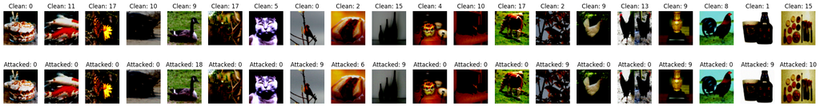

```python
import torch
import torch.nn.functional as F
import matplotlib.pyplot as plt
import random

# Best model obtained from question 3.2
best_model = best_model.to(device)

def pgd_attack(model, input_image, input_label=None,
               epsilon=0.0313,  # Adjusted to match your problem statement
               num_steps=20,
               step_size=0.002,
               clip_value_min=0.,
               clip_value_max=1.0):

    input_image = input_image.clone().detach().requires_grad_(True).to(device)

    # Random initialization around input_image
    random_noise = torch.FloatTensor(input_image.shape).uniform_(-epsilon, epsilon).to(device)
    adv_image = input_image + random_noise
    adv_image = torch.clamp(adv_image, clip_value_min, clip_value_max).detach().requires_grad_(True)

    # If no input label is provided, use the model's prediction
    if input_label is None:
        output = model(adv_image)
        input_label = torch.argmax(output, dim=1).to(device)

    # Perform PGD attack
    for _ in range(num_steps):
        adv_image.requires_grad_(True)  # Ensure requires_grad is True in each iteration
        output = model(adv_image)
        loss = F.cross_entropy(output, input_label)
        model.zero_grad()
        loss.backward()

        # Check if gradient is available before accessing 'data'
        if adv_image.grad is not None:
            gradient = adv_image.grad.data
            adv_image = adv_image + step_size * gradient.sign()
            adv_image = torch.clamp(adv_image, input_image - epsilon, input_image + epsilon)  # Clip to a valid boundary
            adv_image = torch.clamp(adv_image, clip_value_min, clip_value_max).detach()  # Clip pixel values
        else:
            print("Warning: Gradient is None.")

    return adv_image.detach()


# Evaluate model with PGD attack (using the lecture-style PGD attack)
def evaluate_pgd_attack(model, data_loader, eps=0.0313, alpha=0.002, iters=20):
    model.eval()
    correct = 0
    total = 0
    for inputs, labels in data_loader:
        inputs, labels = inputs.to(device), labels.to(device)

        # Use the lecture-style PGD attack
        adv_inputs = pgd_attack(model, inputs, labels, epsilon=eps, num_steps=iters, step_size=alpha)

        outputs = model(adv_inputs)
        _, predicted = torch.max(outputs.data, 1)
        total += labels.size(0)
        correct += (predicted == labels).sum().item()

    robust_accuracy = correct / total
    return robust_accuracy

# Visualize clean and attacked images with their respective labels (using lecture-style PGD attack)
def visualize_attack(model, data_loader, eps=0.0313, alpha=0.002, iters=20, num_images=20):
    model.eval()
    clean_images = []
    attacked_images = []
    clean_labels = []
    attacked_labels = []

    for inputs, labels in data_loader:
        inputs, labels = inputs.to(device), labels.to(device)

        # Perform the attack using the lecture-style PGD attack
        adv_inputs = pgd_attack(model, inputs, labels, epsilon=eps, num_steps=iters, step_size=alpha)

        # Predictions on clean and attacked images
        clean_outputs = model(inputs)
        adv_outputs = model(adv_inputs)

        _, clean_predicted = torch.max(clean_outputs.data, 1)
        _, adv_predicted = torch.max(adv_outputs.data, 1)

        clean_images.extend(inputs[:num_images].cpu().detach().numpy())
        attacked_images.extend(adv_inputs[:num_images].cpu().detach().numpy())
        clean_labels.extend(clean_predicted[:num_images].cpu().numpy())
        attacked_labels.extend(adv_predicted[:num_images].cpu().numpy())

        if len(clean_images) >= num_images:
            break

    clean_images = clean_images[:num_images]
    attacked_images = attacked_images[:num_images]
    clean_labels = clean_labels[:num_images]
    attacked_labels = attacked_labels[:num_images]

    # Plot clean and attacked images with labels
    fig, axs = plt.subplots(2, num_images, figsize=(num_images * 1.5, 4))
    for i in range(num_images):
        # Original image and label
        axs[0, i].imshow(clean_images[i].transpose(1, 2, 0))
        axs[0, i].axis('off')
        axs[0, i].set_title(f"Clean: {clean_labels[i]}")

        # Attacked image and label
        axs[1, i].imshow(attacked_images[i].transpose(1, 2, 0))
        axs[1, i].axis('off')
        axs[1, i].set_title(f"Attacked: {attacked_labels[i]}")

    plt.show()


# Perform the PGD attack evaluation using the lecture-style PGD attack
robust_accuracy = evaluate_pgd_attack(best_model, val_loader, eps=0.0313, alpha=0.002, iters=20)
print(f"Robust Accuracy under PGD attack: {robust_accuracy:.4f}")

# Visualize the first 20 clean and attacked images
visualize_attack(best_model, val_loader, eps=0.0313, alpha=0.002, iters=20, num_images=20)
```

**Question 3.7:** **Train a robust model using adversarial training with PGD ${\epsilon= 0.0313, k=10, \eta= 0.002}$. Write the code for the adversarial training and report the robust accuracies. After finishing the training, you need to store your best robust model in the folder `./models` and load the model to evaluate the robust accuracies for PGD and FGSM attacks with $\epsilon= 0.0313, k=20, \eta= 0.002$ on the testing set.**

[4 points]

```python
import torch
import torch.nn as nn
import torch.optim as optim
import os
import torch.nn.functional as F

# Define the directory to save the model
MODEL_DIR = './models'
if not os.path.exists(MODEL_DIR):
    os.makedirs(MODEL_DIR)

# PGD attack with specific parameters for adversarial training
def adversarial_training(model, train_loader, valid_loader, epsilon=0.0313, k=10, eta=0.002, num_epochs=10):
    optimizer = optim.Adam(model.parameters(), lr=0.0005)
    loss_fn = nn.CrossEntropyLoss()

    best_robust_acc = 0
    best_robust_model = None

    for epoch in range(num_epochs):
        model.train()
        total_loss = 0
        correct = 0
        total = 0

        for inputs, labels in train_loader:
            inputs, labels = inputs.to(device), labels.to(device)

            # Generate adversarial examples using PGD attack for adversarial training
            adv_inputs = pgd_attack(model, inputs, labels, epsilon=epsilon, num_steps=k, step_size=eta)

            # Forward pass
            outputs = model(adv_inputs)
            loss = loss_fn(outputs, labels)

            # Backward pass and optimization
            optimizer.zero_grad()
            loss.backward()
            optimizer.step()

            total_loss += loss.item()
            _, predicted = torch.max(outputs.data, 1)
            total += labels.size(0)
            correct += (predicted == labels).sum().item()

        train_acc = correct / total
        print(f"Epoch {epoch+1}/{num_epochs}, Loss: {total_loss:.4f}, Training Accuracy: {train_acc:.4f}")

        # Validate the model with adversarial examples
        robust_acc = evaluate_pgd_attack(model, valid_loader, eps=epsilon, alpha=eta, iters=k)
        print(f"Robust Accuracy after Epoch {epoch+1}: {robust_acc:.4f}")

        # Save the best robust model
        if robust_acc > best_robust_acc:
            best_robust_acc = robust_acc
            best_robust_model = model.state_dict()

    # Save the best robust model to the './models' folder
    model_path = os.path.join(MODEL_DIR, "best_robust_model.pth")
    torch.save(best_robust_model, model_path)
    print(f"Best robust model saved at {model_path} with robust accuracy of {best_robust_acc:.4f}")

    return model_path, best_robust_acc

# FGSM attack
def fgsm_attack(model, input_image, input_label=None, epsilon=0.0313,
                clip_value_min=0., clip_value_max=1.0):

    input_image = input_image.clone().detach().requires_grad_(True).to(device)

    # If no input label is provided, use the model's prediction
    if input_label is None:
        output = model(input_image)
        input_label = torch.argmax(output, dim=1).to(device)

    # Perform FGSM attack (one step in the direction of the gradient)
    output = model(input_image)
    loss = F.cross_entropy(output, input_label)
    model.zero_grad()
    loss.backward()

    # Gradient step
    gradient = input_image.grad.data
    adv_image = input_image + epsilon * gradient.sign()

    # Clip adversarial images to stay in the valid range
    adv_image = torch.clamp(adv_image, clip_value_min, clip_value_max).detach()

    return adv_image

# Evaluate model with FGSM attack
def evaluate_fgsm_attack(model, data_loader, epsilon=0.0313):
    model.eval()
    correct = 0
    total = 0

    for inputs, labels in data_loader:
        inputs, labels = inputs.to(device), labels.to(device)

        # Use FGSM to generate adversarial examples
        adv_inputs = fgsm_attack(model, inputs, labels, epsilon=epsilon)

        # Make predictions on adversarial examples
        outputs = model(adv_inputs)
        _, predicted = torch.max(outputs.data, 1)
        total += labels.size(0)
        correct += (predicted == labels).sum().item()

    robust_accuracy = correct / total
    return robust_accuracy

# Load the model for evaluation
def load_model_for_evaluation(model_path, model_class, device):
    model = model_class(list_feature_maps=[16, 32, 64], use_skip=True).to(device)  # Ensure you use the correct parameters
    model.load_state_dict(torch.load(model_path))
    return model

# Train the robust model using adversarial training
cnn_adversarial = YourCNN(list_feature_maps=[16, 32, 64], use_skip=True).to(device)
model_path, best_robust_acc = adversarial_training(
    cnn_adversarial, train_loader, val_loader, epsilon=0.0313, k=10, eta=0.002, num_epochs=10
)

# Load the best robust model for evaluation
best_robust_model = load_model_for_evaluation(model_path, YourCNN, device)

# Evaluate the robust model on PGD and FGSM attacks
# PGD attack
robust_accuracy_pgd = evaluate_pgd_attack(best_robust_model, val_loader, eps=0.0313, alpha=0.002, iters=20)
print(f"Robust Accuracy under PGD attack (epsilon=0.0313, k=20, eta=0.002): {robust_accuracy_pgd:.4f}")

# FGSM attack evaluation
robust_accuracy_fgsm = evaluate_fgsm_attack(best_robust_model, val_loader, epsilon=0.0313)
print(f"Robust Accuracy under FGSM attack (epsilon=0.0313): {robust_accuracy_fgsm:.4f}")
```

```
Robust Accuracy after Epoch 1: 0.1468
Robust Accuracy after Epoch 2: 0.1848
Robust Accuracy after Epoch 3: 0.1869
Robust Accuracy after Epoch 4: 0.2038
Robust Accuracy after Epoch 5: 0.1943
Robust Accuracy after Epoch 6: 0.2228
Robust Accuracy after Epoch 7: 0.2165
Robust Accuracy after Epoch 8: 0.1964
Robust Accuracy after Epoch 9: 0.2239
Robust Accuracy after Epoch 10: 0.2144
Best robust model saved at ./models/best_robust_model.pth with robust accuracy of 0.2239
```

```
Robust Accuracy under PGD attack (epsilon=0.0313, k=20, eta=0.002): 0.1700
Robust Accuracy under FGSM attack (epsilon=0.0313): 0.2260
```

**Question 3.8 (Kaggle competition)**

You can reuse the best model obtained in this assignment or develop new models to evaluate on the **testing set of the FIT3181/5215 Kaggle competion**. However, to gain any points for this question, your testing accuracy must **exceed** the accuracy threshold from a base model developed by us as shown in the leader board of the competition.

The marks for this question are as follows:

- If you are in *top 10%* of your cohort, you gain *10 points*.
- If you are in *top 20%* of your cohort, you gain *8 points*.
- If you are in *top 30%* of your cohort, you gain *6 points*.
- If you *beat* our base model, you gain *4 points*.

END OF ASSIGNMENT

GOOD LUCK WITH YOUR ASSIGNMENT 1!